# 8-Heteroscedasticity

Author: Rick Dean

Article date: 2021-04-26

Abstract

The following notes and scripts are based on the following sources: [Introductory Econometrics - A Modern Approach](https://www.amazon.com/Introductory-Econometrics-Modern-Approach-Standalone/dp/130527010X/ref=sr_1_2?dchild=1&keywords=Introductory+Econometrics%3A+A+Modern+Approach&qid=1597005903&s=books&sr=1-2) by Jeffrey M. Wooldridge is the main text for the statistical content. This text will be referenced as `(Wooldridge)`.

The companion text [Using R for Introductory Econometrics](http://www.urfie.net/index.html) by Florian Heiss provides specific R scripts in support of the main text and the inspiration for my scripts, notes and graphics. I will reference this document as `(Heiss)`. The following is from **Part 1 - Regression Analysis with Cross-Sectional Data, Chapter 8 Heteroscedasticity** of `(Heiss)`.

```r
library(knitr)
library(kableExtra)
library(data.table)
library(lmtest)
library(car)
library(RregressPkg)
library(RplotterPkg)
library(wooldridge)
```

# 8 Heteroscedasticity

## 8.1 Heteroscedasticity-Robust inference

`(Wooldridge)` presents a derivation of $Var(\hat{\beta_{1}})$ when heteroskedasticity is present (Equation 8.4, page 245) based on White(1980). `(Heiss)` suggests the function *car::hccm()* (*h*eteroscedasticity-*c*orrected *c*ovariance *m*atrices) that offers serveral versions of the White formula.

Since the variance of $\hat{\beta_{i}}$ influences the standard errors, t statistics, and $p$ values, `(Wooldridge)` suggest the *lmtest::coeftest()* which accepts an argument for incorporating White’s estimates of the variance-covariance matrix of the coefficients.

For performing $F$-test, `(Wooldridge)` notes that *car::linearHypothesis()* function also accepts an argument for incorporating White’s estimates.

Task: Compare the usual estimates of variance-covariance and associated tests with White’s estimates when heteroscedasticity is suggested in the data.

1. Set up the data:

```r
data("gpa3", package="wooldridge")
gpa3_dt <- data.table::setDT(gpa3)
gpa3_dt <- gpa3_dt[spring == 1, .(cumgpa, sat, hsperc, tothrs, female, black, white)]
```

2. Define the linear model:

```r
formula_obj <- cumgpa ~ sat + hsperc + tothrs + female + black + white
```

3. Estimate the ols:

```r
gpa3_ols <- RregressPkg::ols_calc(df = gpa3_dt, formula_obj = formula_obj)
RplotterPkg::create_table(gpa3_ols$coef_df)
```

| Coef | Value | SE | t_value | p_Value |
| --- | --- | --- | --- | --- |
| (Intercept) | 1.470064766 | 0.2298030843 | 6.3970628 | 4.942236e-10 |
| sat | 0.001140728 | 0.0001785594 | 6.3885044 | 5.197000e-10 |
| hsperc | -0.008566358 | 0.0012404218 | -6.9060035 | 2.274950e-11 |
| tothrs | 0.002503998 | 0.0007309854 | 3.4255106 | 6.846704e-04 |
| female | 0.303433294 | 0.0590203313 | 5.1411656 | 4.496543e-07 |
| black | -0.128283685 | 0.1473701249 | -0.8704864 | 3.846164e-01 |
| white | -0.058721727 | 0.1409895593 | -0.4164970 | 6.772953e-01 |

4. Estimate the variance-covariance and ols statistics with White’s formulas:

```r
gpa3_lm <- lm(formula_obj, data = gpa3_dt)
lmtest::coeftest(gpa3_lm, vcov=car::hccm)
```

```
##
## t test of coefficients:
##
##                Estimate  Std. Error t value  Pr(>|t|)
## (Intercept)  1.47006477  0.22938036  6.4089 4.611e-10 ***
## sat          0.00114073  0.00019532  5.8402 1.169e-08 ***
## hsperc      -0.00856636  0.00144359 -5.9341 6.963e-09 ***
## tothrs       0.00250400  0.00074930  3.3418   0.00092 ***
## female       0.30343329  0.06003964  5.0539 6.911e-07 ***
## black       -0.12828368  0.12818828 -1.0007   0.31762
## white       -0.05872173  0.12043522 -0.4876   0.62615
## ---
## Signif. codes:  0 '***' 0.001 '**' 0.01 '*' 0.05 '.' 0.1 ' ' 1
```

5. Show the regular variance-covariance matrix:

```r
regular_var_cov <- gpa3_ols$var_cov
regular_var_cov[lower.tri(regular_var_cov)] <- NA
RplotterPkg::create_table(regular_var_cov)
```

|  | (Intercept) | sat | hsperc | tothrs | female | black | white |
| --- | --- | --- | --- | --- | --- | --- | --- |
| (Intercept) | 0.0528095 | -3.04e-05 | -0.0001476 | -4.64e-05 | -0.0027233 | -0.0207443 | -0.0160372 |
| sat | NA | 0.00e+00 | 0.0000001 | 0.00e+00 | 0.0000005 | 0.0000020 | -0.0000035 |
| hsperc | NA | NA | 0.0000015 | 1.00e-07 | 0.0000175 | 0.0000146 | 0.0000092 |
| tothrs | NA | NA | NA | 5.00e-07 | 0.0000011 | -0.0000063 | -0.0000051 |
| female | NA | NA | NA | NA | 0.0034834 | 0.0009256 | 0.0006864 |
| black | NA | NA | NA | NA | NA | 0.0217180 | 0.0184517 |
| white | NA | NA | NA | NA | NA | NA | 0.0198781 |

6. Show the White variance-covariance matrix:

```r
white_var_cov <- car::hccm(gpa3_lm)
white_var_cov[lower.tri(white_var_cov)] <- NA
RplotterPkg::create_table(white_var_cov)
```

|  | (Intercept) | sat | hsperc | tothrs | female | black | white |
| --- | --- | --- | --- | --- | --- | --- | --- |
| (Intercept) | 0.0526153 | -3.52e-05 | -0.0001785 | -3.75e-05 | -0.0022511 | -0.0177743 | -0.0113449 |
| sat | NA | 0.00e+00 | 0.0000001 | 0.00e+00 | -0.0000001 | 0.0000056 | -0.0000031 |
| hsperc | NA | NA | 0.0000021 | 1.00e-07 | 0.0000161 | 0.0000215 | 0.0000285 |
| tothrs | NA | NA | NA | 6.00e-07 | -0.0000004 | -0.0000184 | -0.0000103 |
| female | NA | NA | NA | NA | 0.0036048 | 0.0010981 | 0.0010131 |
| black | NA | NA | NA | NA | NA | 0.0164322 | 0.0126796 |
| white | NA | NA | NA | NA | NA | NA | 0.0145046 |

It appears that White’s estimates return nearly the same variances and standard errors for the coefficients.

Task: Compute the $F$-tests with both the regular and White’s alternative variance-covariance estimates using *car::linearHypothesis()*.

1. Set the null hypothesis that *black* = *white* = 0

```r
null_hypoth <- c("black","white")
```

2. Compute the regular $F$-test:

```r
car::linearHypothesis(gpa3_lm, null_hypoth)
```

```
## Linear hypothesis test
##
## Hypothesis:
## black = 0
## white = 0
##
## Model 1: restricted model
## Model 2: cumgpa ~ sat + hsperc + tothrs + female + black + white
##
##   Res.Df    RSS Df Sum of Sq      F Pr(>F)
## 1    361 79.362
## 2    359 79.062  2   0.29934 0.6796 0.5075
```

3. Compute the $F$-test with White’s estimates for variance-covariance:

```r
car::linearHypothesis(gpa3_lm, null_hypoth, vcov=car::hccm)
```

```
## Linear hypothesis test
##
## Hypothesis:
## black = 0
## white = 0
##
## Model 1: restricted model
## Model 2: cumgpa ~ sat + hsperc + tothrs + female + black + white
##
## Note: Coefficient covariance matrix supplied.
##
##   Res.Df Df      F Pr(>F)
## 1    361
## 2    359  2 0.6725 0.5111
```

## 8.2 Heteroscedasticity tests

Task: Investigate Heteroskedasticity in a Housing Price Equation.

1. Set up the data:

```r
data("hprice1", package = "wooldridge")
hprice1_dt <- data.table::setDT(hprice1)
hprice1_dt <- hprice1_dt[, .(price, lotsize, sqrft, bdrms)]
```

2. Define the model formula:

```r
formula_obj <- price ~ lotsize + sqrft + bdrms
```

3. Plot the model residuals:

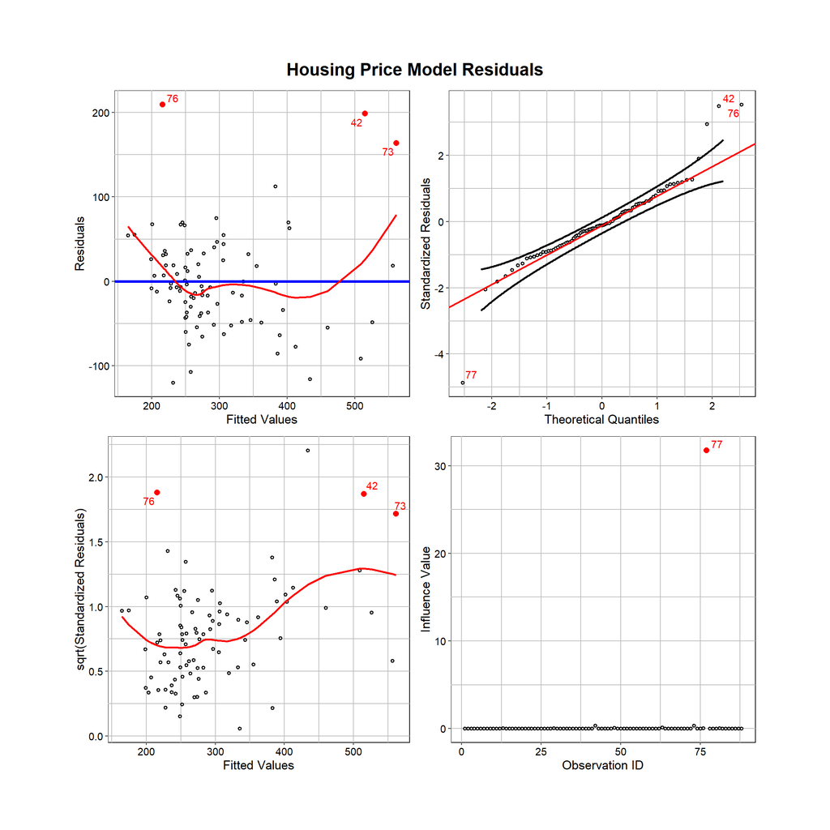

```r
RregressPkg::plot_residuals_check(
  df = hprice1_dt,
  formula_obj = formula_obj,
  residual_label_threshold = 150.0,
  leverage_label_threshold = 30.0,
  title = "Housing Price Model Residuals"
)
```

4. Run Breusch-Pagan Test for Heteroskedasticity:

```r
BP_test_df <- RregressPkg::ols_BP_test_calc(
  df = hprice1_dt,
  formula_obj = formula_obj
)
RplotterPkg::create_table(
  x = BP_test_df,
  caption = "BP Test Housing Price Residuals"
)
```

BP Test Housing Price Residuals

| Statistic | Value | p.Value |
| --- | --- | --- |
| F | 5.338919 | 0.002047744 |
| LM | 14.092386 | 0.002782060 |

Take Away: The $p-values$ indicate strong evidence against the null hypothesis of homoskedasticity of variance. The square of the estimated error term is a function of the predictor coefficients.

### Logarithmic functional form of the formula object

Chapter 6 of “Introductory Econometrics” suggest a reduction of heteroskedasticity by using the logarithmic functional form.

1. Define the model formula:

```r
log_formula_obj <- log(price) ~ log(lotsize) + log(sqrft) + bdrms
```

2. Plot the model residuals:

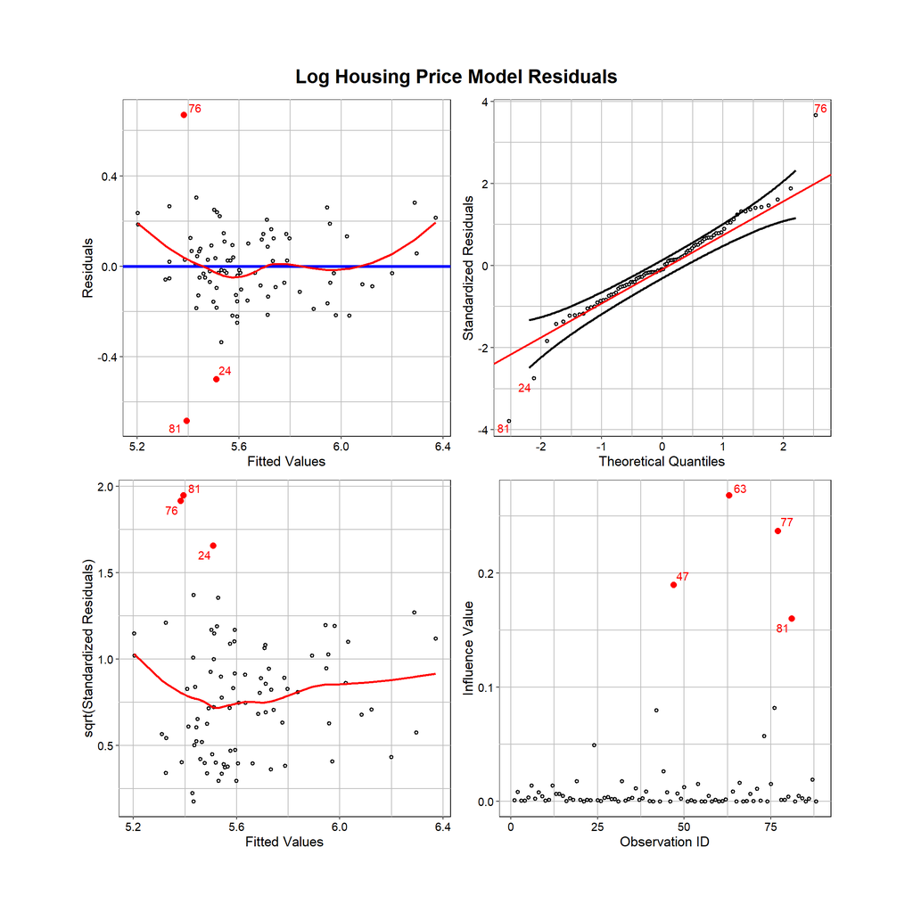

```r
RregressPkg::plot_residuals_check(
  df = hprice1_dt,
  formula_obj = log_formula_obj,
  residual_label_threshold = 0.4,
  leverage_label_threshold = 0.15,
  title = "Log Housing Price Model Residuals"
)
```

3. Run Breusch-Pagan Test for Heteroskedasticity:

```r
BP_test_df <- RregressPkg::ols_BP_test_calc(
  df = hprice1_dt,
  formula_obj = log_formula_obj
)
RplotterPkg::create_table(
  x = BP_test_df,
  caption = "BP Test Log Housing Price Residuals"
)
```

BP Test Log Housing Price Residuals

| Statistic | Value | p.Value |
| --- | --- | --- |
| F | 1.411500 | 0.2451457 |
| LM | 4.223246 | 0.2383448 |

Take Away: Based on the $p-values$ we fail to reject the null hypothesis where the square of the estimated error term is not a function of the predictor coefficients.